# Trait pathways, everyone pooled

Which gene sets lead each trait’s protein ranking? For every window and trait, proteins are ranked by the limma t that `01_Trait_Associations` saved for that pairing (change score), and fgsea tests every set on the ranking, one database at a time. The step ends by choosing, per window, the sets the trait pathway figure draws, grouping near-duplicates into a tree as `02_HRvLR/02_Set_Contrasts` does. fgsea treats proteins as independent, so a large set of co-moving proteins can look stronger than the 16 people behind it support (Wu and Smyth 2012).

## Packages

```r
library(here)
library(dplyr)
library(tidyr)
library(purrr)
library(ggplot2)
source(here("00_Setup", "Shared_functions", "set_tree.R"))
source(here("00_Setup", "Shared_functions", "workbooks.R"))
inputs <- c(
  associations = "03_Continuous/01_Trait_Associations/c_data/trait_associations.rds",
  gene_sets = "01_Processing/04_Gene_Sets/c_data/gene_sets.rds"
)
paths <- vapply(inputs, here, character(1))
stopifnot(file.exists(paths))
```

## Input

The protein change scores, kept to the one protein that represents each gene in the sets, and the tested sets.

```r
gs <- readRDS(paths[["gene_sets"]])
catalog <- filter(gs$set_catalog, qualifies)
sets <- gs$sets[catalog$set_id]
chosen <- filter(gs$protein_map, selected)
gene_of <- set_names(chosen$gene, chosen$uniprot_id)
protein_t <- readRDS(paths[["associations"]])$change_score |>
  filter(feature_type == "proteins", feature %in% chosen$uniprot_id) |>
  select(window, trait, feature, t)
window_order <- unique(protein_t$window)
count(protein_t, window, name = "protein_trait_pairs")
```

```
# A tibble: 6 × 2
  window          protein_trait_pairs
  <chr>                         <int>
1 acute                         16464
2 baseline                      16464
3 baseline_level                12348
4 post_bout_level               12348
5 post_level                    12348
6 training                      16464
```

## fgsea per window, trait and database

fgsea receives one window-and-trait ranking (limma t, named by gene) and one database’s sets, and returns each set’s normalised enrichment score (NES), p and FDR. It runs one database at a time, so each `fdr` is Benjamini-Hochberg within one database and one ranking. fgsea estimates p by permutation, so it is seeded. When a ranking leans one way, fgsea cannot estimate p for some sets and leaves p, NES and FDR missing; `nPermSimple = 10000` keeps those few. They are listed below and count as tested but never as calls.

```r
set.seed(1)
by_db <- split(catalog$set_id, catalog$collection)
rankings <- protein_t |>
  nest(.by = c(window, trait)) |>
  mutate(stats = map(data, \(d) set_names(d$t, gene_of[d$feature])), .keep = "unused")
pathways <- rankings |>
  expand_grid(collection = names(by_db)) |>
  mutate(tests = map2(stats, collection, \(stats, db) {
    fgsea::fgsea(sets[by_db[[db]]], stats, minSize = 15, maxSize = 500, nPermSimple = 10000) |>
      as_tibble() |>
      transmute(
        set_id = pathway, n_proteins = size, nes = NES, p = pval, fdr = padj,
        leading_edge = map_chr(leadingEdge, \(x) paste(x, collapse = ";"))
      )
  })) |>
  select(-stats) |>
  unnest(tests) |>
  left_join(select(catalog, set_id, pathway), by = "set_id")
counts <- pathways |>
  summarise(
    n_tested = n(), n_nominal = sum(p < 0.05, na.rm = TRUE),
    n_fdr_05 = sum(fdr < 0.05, na.rm = TRUE),
    n_up = sum(fdr < 0.05 & nes > 0, na.rm = TRUE),
    n_down = sum(fdr < 0.05 & nes < 0, na.rm = TRUE), .by = c(window, trait, collection)
  )
pathways |>
  filter(is.na(p)) |>
  select(window, trait, collection, pathway, n_proteins)
```

```
# A tibble: 12 × 5
   window   trait            collection pathway                       n_proteins
   <chr>    <chr>            <chr>      <chr>                              <int>
 1 training pct_fcsa_mixed   GO_Slim    nucleobase-containing small …        265
 2 training pct_fcsa_mixed   GO_Slim    transmembrane transport              261
 3 training pct_mcsa         GO_Slim    transmembrane transport              261
 4 training comp_hypertrophy GO_Slim    generation of precursor meta…        232
 5 training comp_hypertrophy GO_Slim    transmembrane transport              261
 6 training comp_hypertrophy GOBP       GOBP_CELLULAR_RESPIRATION            181
 7 training comp_hypertrophy GOBP       GOBP_GENERATION_OF_PRECURSOR…        232
 8 training comp_hypertrophy GOBP       GOBP_RIBOSE_PHOSPHATE_METABO…        160
 9 training comp_hypertrophy Hallmark   HALLMARK_OXIDATIVE_PHOSPHORY…        156
10 training comp_hypertrophy Reactome   REACTOME_AEROBIC_RESPIRATION…        165
11 acute    pct_mcsa         GO_Slim    transmembrane transport              261
12 acute    pct_mcsa         GOBP       GOBP_GENERATION_OF_PRECURSOR…        232
```

```r
counts |>
  summarise(across(c(n_tested, n_fdr_05), sum), .by = window)
```

```
# A tibble: 6 × 3
  window          n_tested n_fdr_05
  <chr>              <int>    <int>
1 baseline_level      8532      950
2 baseline           11376      424
3 training           11376      306
4 post_level          8532      699
5 acute              11376      858
6 post_bout_level     8532      393
```

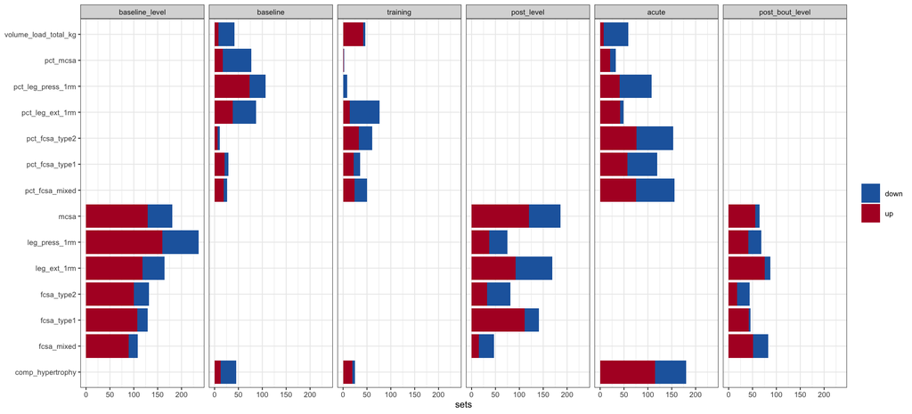

Figure 1: Sets at fgsea FDR < 0.05 per trait ranking, up and down, all databases.

```r
counts |>
  summarise(across(c(n_up, n_down), sum), .by = c(window, trait)) |>
  pivot_longer(c(n_up, n_down), names_to = "direction") |>
  mutate(window = factor(window, window_order)) |>
  ggplot(aes(value, trait, fill = direction)) +
  geom_col() +
  facet_wrap(~window, nrow = 1) +
  scale_fill_manual(
    values = c(n_up = "#B2182B", n_down = "#2166AC"), labels = c(n_up = "up", n_down = "down")
  ) +
  labs(x = "sets", y = NULL, fill = NULL) +
  theme_bw(base_size = 8)
```

## Sets for the trait pathway figure

A set is a candidate for a window when fgsea calls it at FDR < 0.05 against at least one of the window’s traits (GO Slim excluded, as in `02_Set_Contrasts`). Candidates are ranked by whether their calls agree in sign, then by summed |NES| across the window’s traits.

```r
candidates <- pathways |>
  filter(collection != "GO_Slim") |>
  summarise(
    hits = sum(fdr < 0.05, na.rm = TRUE),
    same_sign = n_distinct(sign(nes[which(fdr < 0.05)])) == 1,
    strength = sum(abs(nes), na.rm = TRUE), best_p = min(p, na.rm = TRUE),
    n_proteins = first(n_proteins), .by = c(window, set_id, collection)
  ) |>
  filter(hits >= 1) |>
  arrange(window, desc(same_sign), desc(strength)) |>
  mutate(rank = row_number(), .by = window)
count(candidates, window)
```

```
# A tibble: 6 × 2
  window              n
  <chr>           <int>
1 acute             280
2 baseline          188
3 baseline_level    309
4 post_bout_level   182
5 post_level        371
6 training          143
```

Near-duplicate sets are grouped, not dropped. Within each window, sets are clustered by the proteins they share (Jaccard similarity: shared ÷ union; average linkage), and the tree is cut at three heights, as in `02_Set_Contrasts`. Each cluster is shown by its most specific set: the smallest whose best p across the window’s traits is within 10-fold of the cluster’s best. The figure draws one set per cluster at height 0.85.

```r
trait_selection <- candidates |>
  group_by(window) |>
  group_modify(\(d, key) set_tree(d, sets)) |>
  ungroup() |>
  mutate(
    representative_0.75 = most_specific(cut_0.75, best_p, n_proteins),
    representative_0.85 = most_specific(cut_0.85, best_p, n_proteins),
    representative_0.9 = most_specific(cut_0.9, best_p, n_proteins), .by = window
  ) |>
  left_join(select(catalog, set_id, pathway), by = "set_id")
trait_selection |>
  summarise(candidates = n(), across(starts_with("representative"), sum), .by = window)
```

```
# A tibble: 6 × 5
  window   candidates representative_0.75 representative_0.85 representative_0.9
  <chr>         <int>               <int>               <int>              <int>
1 acute           280                 105                  71                 52
2 baseline        188                  60                  39                 32
3 baselin…        309                  69                  50                 42
4 post_bo…        182                  50                  36                 32
5 post_le…        371                 114                  80                 56
6 training        143                  43                  32                 25
```

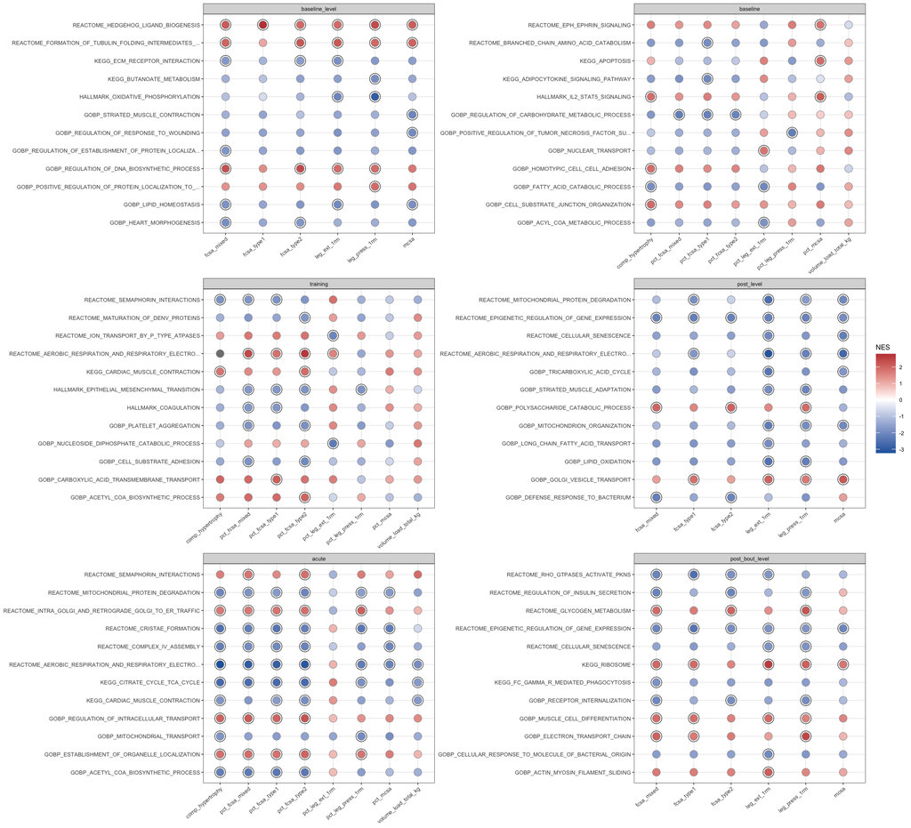

Figure 2: Up to 12 representative sets (cut 0.85) per window: NES per trait; ring: FDR < 0.05.

```r
drawn <- trait_selection |>
  filter(representative_0.85) |>
  slice_min(rank, n = 12, by = window)
pathways |>
  semi_join(drawn, by = c("window", "set_id")) |>
  mutate(
    window = factor(window, window_order),
    label = stringr::str_trunc(pathway, 55)
  ) |>
  ggplot(aes(trait, label, fill = nes)) +
  geom_point(shape = 21, size = 3, colour = "grey60") +
  geom_point(data = \(d) filter(d, fdr < 0.05), shape = 1, size = 4.2, colour = "black") +
  scale_fill_gradient2(low = "#2166AC", high = "#B2182B", name = "NES") +
  facet_wrap(~window, scales = "free", ncol = 2) +
  labs(x = NULL, y = NULL) +
  theme_bw(base_size = 6) +
  theme(axis.text.x = element_text(angle = 40, hjust = 1))
```

## Validation

```r
stopifnot(
  all(pathways$set_id %in% catalog$set_id), all(pathways$fdr >= pathways$p, na.rm = TRUE),
  all(trait_selection$set_id %in% catalog$set_id),
  !anyDuplicated(select(pathways, window, trait, set_id))
)
```

## Summary

1422 sets in 5 databases ranked against 42 window and trait pairs: 3630 set calls at FDR < 0.05 in total, the most for one pair 236. 308 sets represent the windows in the trait pathway figure.

## Save

`trait_pathways.rds` holds the fgsea table and the selection for the figure.

```r
out <- here("03_Continuous", "02_Trait_Pathways", "c_data")
dir.create(out, showWarnings = FALSE)
saveRDS(
  list(pathways = pathways, trait_selection = trait_selection),
  file.path(out, "trait_pathways.rds")
)
write_workbook(
  list(
    counts = counts,
    trait_pathways = arrange(pathways, match(window, window_order), trait, collection, p),
    trait_selection = trait_selection
  ),
  c(
    "Per window, trait and database: sets tested, at p < 0.05, at FDR < 0.05 (up, down).",
    "Per window, trait and set: fgsea NES, p, FDR within the database, leading edge.",
    "Per window: candidate sets, rank, tree clusters at three cuts and the representative of each."
  ),
  file.path(out, "trait_pathways.xlsx"), inputs, paths
)
```